# Pemodelan ARIMA - Suhu Rata-rata Harian Jakarta (Kemayoran)

Maul

1 Oktober 2026

# 1 Packages

```r
library(readxl)
library(forecast)
library(tseries)
library(MASS)
library(TSA)
library(lmtest)
```

# 2 Data dan Eksplorasi

Data yang digunakan adalah **suhu rata-rata harian (TG, °C) di stasiun Jakarta Kemayoran** yang dikumpulkan pada awal perkuliahan. Data terdiri atas 517 amatan harian (17 September 2011 s.d. 14 Februari 2013), sehingga memenuhi syarat minimal 500 amatan.

```r
raw <- read_excel("Data_MPDW_Maul__3_.xlsx")
# seluruh kolom tersimpan sebagai satu kolom teks "Date,Period,TG" -> dipisah dahulu
sp  <- do.call(rbind, strsplit(raw[[1]], ","))
dat <- data.frame(Date = as.Date(sp[,1]), Period = as.integer(sp[,2]), TG = as.numeric(sp[,3]))
cat("Jumlah amatan :", nrow(dat), "\nData hilang   :", sum(is.na(dat)),
    "\nTanggal rapat :", all(diff(dat$Date) == 1), "\n")
```

```
## Jumlah amatan : 517
## Data hilang   : 0
## Tanggal rapat : TRUE
```

```r
summary(dat$TG)
```

```
##    Min. 1st Qu.  Median    Mean 3rd Qu.    Max.
##   24.00   28.50   29.20   29.08   29.80   31.80
```

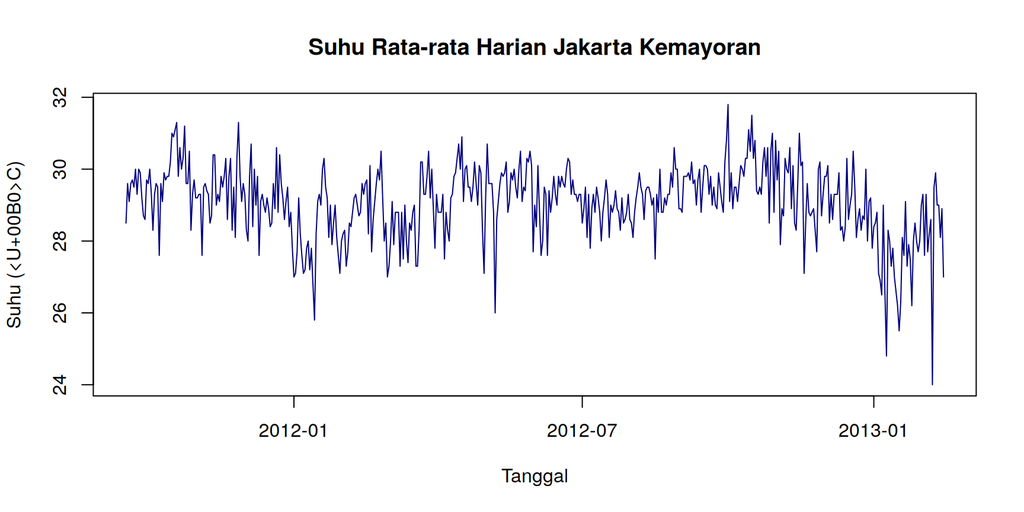

```r
plot(dat$Date, dat$TG, type = "l", col = "navyblue", xlab = "Tanggal", ylab = "Suhu (°C)",
     main = "Suhu Rata-rata Harian Jakarta Kemayoran")
```

Data bergerak di sekitar 29 °C tanpa tren yang jelas, dengan beberapa penurunan tajam (suhu rendah pada hari-hari hujan) terutama menjelang akhir periode.

# 3 Tahap 1: Pembagian Data Latih dan Data Uji

Data tidak memiliki pola musiman atau tren yang tegas, sehingga pembagian dilakukan secara berurutan dengan proporsi sekitar **80:20**: 414 amatan pertama sebagai data latih dan 103 amatan terakhir sebagai data uji.

```r
n.train <- 414
train <- dat$TG[1:n.train]
test  <- dat$TG[(n.train + 1):nrow(dat)]
c(latih = length(train), uji = length(test))
```

```
## latih   uji
##   414   103
```

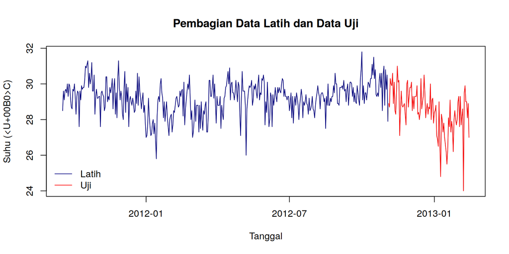

```r
plot(dat$Date, dat$TG, type = "l", col = "grey60", xlab = "Tanggal", ylab = "Suhu (°C)",
     main = "Pembagian Data Latih dan Data Uji")
lines(dat$Date[1:n.train], train, col = "navyblue")
lines(dat$Date[(n.train + 1):nrow(dat)], test, col = "red")
legend("bottomleft", c("Latih", "Uji"), col = c("navyblue", "red"), lty = 1, bty = "n")
```

# 4 Tahap 2: Uji Stasioneritas Data Latih

## 4.1 Stasioneritas dalam Rataan (Plot, ACF, dan Uji ADF)

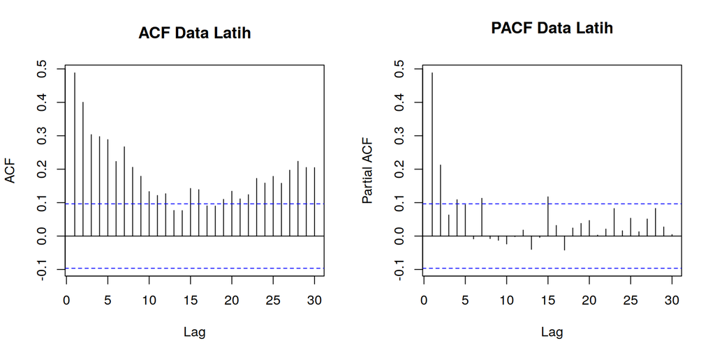

```r
par(mfrow = c(1, 2))
acf(train, lag.max = 30, main = "ACF Data Latih")
pacf(train, lag.max = 30, main = "PACF Data Latih")
```

```r
par(mfrow = c(1, 1))
```

Plot ACF menurun secara lambat (*tails off* perlahan) dan masih signifikan hingga lag-lag yang cukup jauh, yang mengindikasikan adanya ketidakstasioneran dalam rataan.

```r
tseries::adf.test(train)
```

```
##
##  Augmented Dickey-Fuller Test
##
## data:  train
## Dickey-Fuller = -4.4489, Lag order = 7, p-value = 0.01
## alternative hypothesis: stationary
```

$H_0$ : data tidak stasioner dalam rataan, $H_1$ : data stasioner dalam rataan. Uji ADF memberikan *p-value* < 0,05 sehingga tolak $H_0$. Terdapat **ketidaksesuaian** antara uji ADF (menyatakan stasioner) dan plot ACF (meluruh sangat lambat). Uji ADF cenderung menolak $H_0$ pada data yang berfluktuasi di sekitar rataan tetap, sedangkan pola ACF yang meluruh lambat menunjukkan ketergantungan jangka panjang yang kuat. Dengan pertimbangan tersebut, untuk kehati-hatian dilakukan *differencing* (lihat Tahap 3), lalu pemilihan model dilihat dari AIC dan diagnostik sisaan.

## 4.2 Stasioneritas dalam Ragam (Box-Cox)

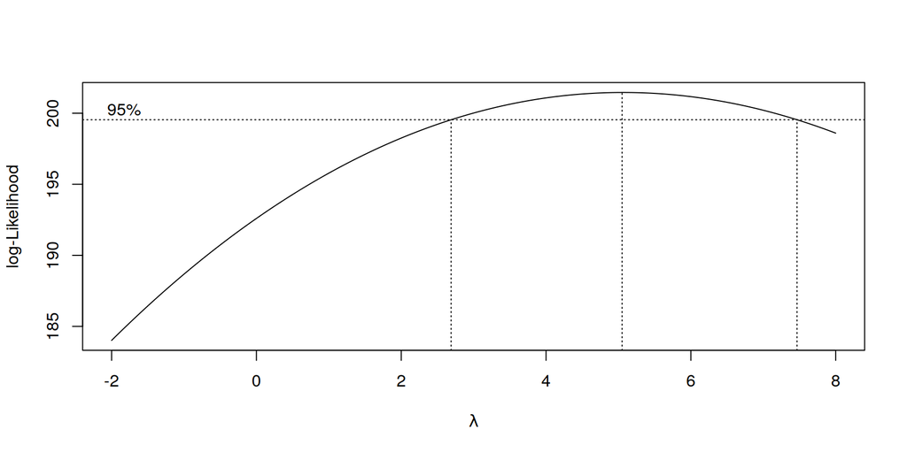

```r
index <- seq_along(train)
bc <- boxcox(train ~ index, lambda = seq(-2, 8, by = 0.05))
```

```r
lambda.opt <- bc$x[which.max(bc$y)]
ci <- range(bc$x[bc$y > max(bc$y) - qchisq(0.95, 1)/2])
cat("Lambda optimum :", lambda.opt, "\nSelang kepercayaan 95% : [", ci[1], ",", ci[2], "]\n")
```

```
## Lambda optimum : 5.05
## Selang kepercayaan 95% : [ 2.7 , 7.45 ]
```

Selang kepercayaan 95% bagi $\lambda$ adalah [2.7, 7.45] dan **tidak memuat nilai 1**, sehingga data latih belum stasioner dalam ragam dan perlu ditransformasi.

# 5 Tahap 3: Penanganan Ketidakstasioneran

## 5.1 Transformasi Box-Cox (ragam)

Digunakan $\lambda = 5$ (pembulatan dari $\lambda$ optimum yang berada di dalam selang kepercayaan).

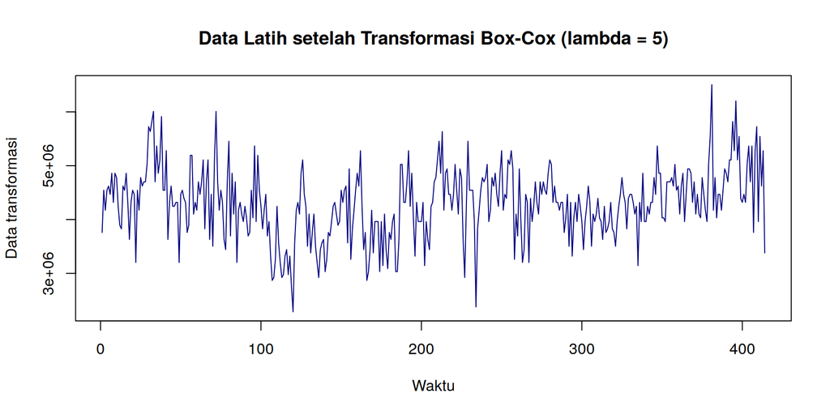

```r
lambda <- 5
z <- BoxCox(train, lambda)
plot(z, type = "l", col = "navyblue", xlab = "Waktu", ylab = "Data transformasi",
     main = "Data Latih setelah Transformasi Box-Cox (lambda = 5)")
```

## 5.2 Differencing (rataan)

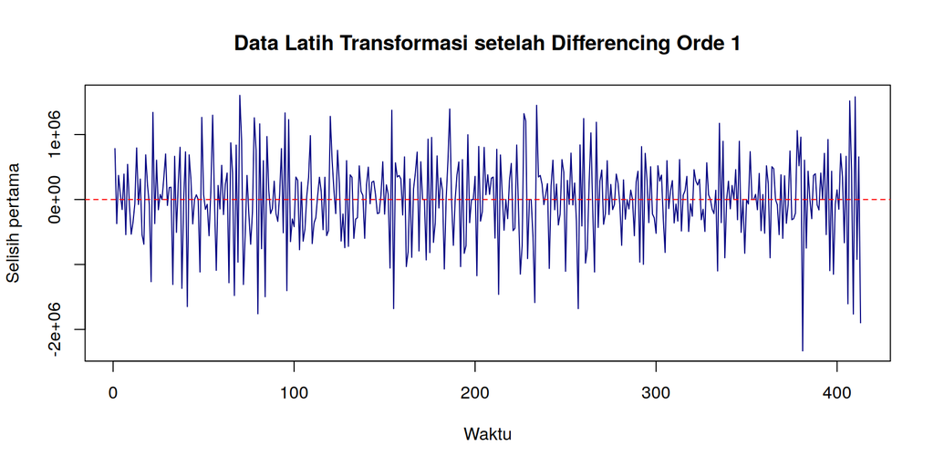

```r
dz <- diff(z)
plot(dz, type = "l", col = "navyblue", xlab = "Waktu", ylab = "Selisih pertama",
     main = "Data Latih Transformasi setelah Differencing Orde 1")
abline(h = 0, col = "red", lty = 2)
```

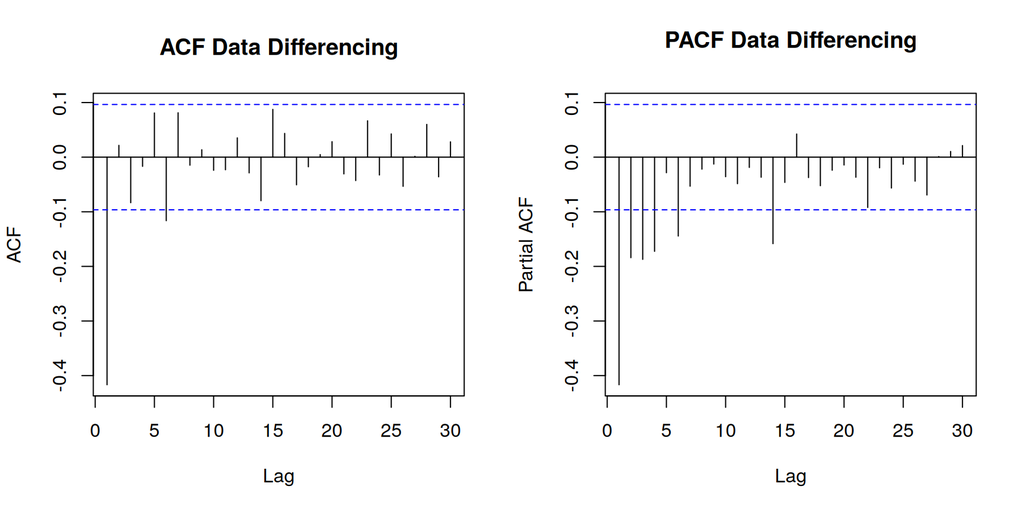

```r
par(mfrow = c(1, 2))
acf(dz, lag.max = 30, main = "ACF Data Differencing")
pacf(dz, lag.max = 30, main = "PACF Data Differencing")
```

```r
par(mfrow = c(1, 1))
tseries::adf.test(dz)
```

```
##
##  Augmented Dickey-Fuller Test
##
## data:  dz
## Dickey-Fuller = -10.127, Lag order = 7, p-value = 0.01
## alternative hypothesis: stationary
```

Setelah transformasi dan *differencing* orde 1, data berfluktuasi di sekitar 0 dengan pita yang relatif konstan, ACF tidak lagi meluruh lambat, dan uji ADF memberikan *p-value* < 0,05 sehingga data stasioner dalam rataan. Dengan demikian digunakan $d = 1$.

# 6 Tahap 4: Identifikasi Model Potensial

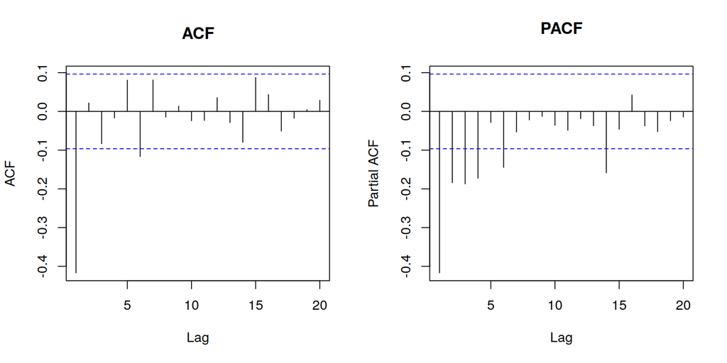

```r
par(mfrow = c(1, 2))
acf(dz, lag.max = 20, main = "ACF"); pacf(dz, lag.max = 20, main = "PACF")
```

```r
par(mfrow = c(1, 1))
TSA::eacf(dz)
```

```
## AR/MA
##   0 1 2 3 4 5 6 7 8 9 10 11 12 13
## 0 x o o o o x o o o o o  o  o  o
## 1 x x o o o o o o o o o  o  o  o
## 2 x x x o o o o o o o o  o  o  o
## 3 x x x o o o o o o o o  o  o  o
## 4 x x x x o o o o o o o  o  o  o
## 5 x x x o o x o o o o o  o  o  o
## 6 x o o x x o o o o o o  o  o  o
## 7 x o o o x o o o o o o  o  o  o
```

- **ACF** *cuts off* setelah lag 1 (lag 1 sekitar -0,42) sehingga mengarah ke **MA(1)**, yaitu ARIMA(0,1,1).
- **PACF** meluruh (*tails off*) dengan beberapa lag awal signifikan, konsisten dengan komponen MA.
- **EACF** memperlihatkan segitiga simbol “o” yang berpuncak di (AR=0, MA=1), sejalan dengan ACF (MA(1)). Model di sekitar puncak tersebut, yaitu (AR=1, MA=1), (AR=0, MA=2), dan (AR=1, MA=2), ikut dipertimbangkan, ditambah ARIMA(2,1,1) sebagai kandidat dengan satu suku AR tambahan karena PACF masih menunjukkan beberapa lag awal yang signifikan.

Model tentatif: ARIMA(0,1,1), ARIMA(1,1,1), ARIMA(2,1,1), ARIMA(0,1,2), dan ARIMA(1,1,2).

# 7 Tahap 5: Pendugaan Parameter, Signifikansi, dan AIC

Model diduga pada data latih dengan transformasi Box-Cox ($\lambda = 5$) yang ditangani langsung oleh fungsi `Arima()` sehingga ramalan otomatis dikembalikan ke skala asli (°C).

```r
m011 <- Arima(train, order = c(0,1,1), lambda = lambda)
m111 <- Arima(train, order = c(1,1,1), lambda = lambda)
m211 <- Arima(train, order = c(2,1,1), lambda = lambda)
m012 <- Arima(train, order = c(0,1,2), lambda = lambda)
m112 <- Arima(train, order = c(1,1,2), lambda = lambda)
models <- list("ARIMA(0,1,1)" = m011, "ARIMA(1,1,1)" = m111, "ARIMA(2,1,1)" = m211,
               "ARIMA(0,1,2)" = m012, "ARIMA(1,1,2)" = m112)
for (nm in names(models)) { cat("\n====", nm, "====\n"); print(coeftest(models[[nm]])) }
```

```
##
## ==== ARIMA(0,1,1) ====
##
## z test of coefficients:
##
##      Estimate Std. Error z value  Pr(>|z|)
## ma1 -0.697963   0.048614 -14.357 < 2.2e-16 ***
## ---
## Signif. codes:  0 '***' 0.001 '**' 0.01 '*' 0.05 '.' 0.1 ' ' 1
##
##
## ==== ARIMA(1,1,1) ====
##
## z test of coefficients:
##
##      Estimate Std. Error  z value  Pr(>|z|)
## ar1  0.310295   0.061785   5.0221  5.11e-07 ***
## ma1 -0.921337   0.031847 -28.9301 < 2.2e-16 ***
## ---
## Signif. codes:  0 '***' 0.001 '**' 0.01 '*' 0.05 '.' 0.1 ' ' 1
##
##
## ==== ARIMA(2,1,1) ====
##
## z test of coefficients:
##
##      Estimate Std. Error  z value  Pr(>|z|)
## ar1  0.297738   0.054017   5.5119 3.549e-08 ***
## ar2  0.153356   0.053115   2.8872  0.003887 **
## ma1 -0.950355   0.020046 -47.4092 < 2.2e-16 ***
## ---
## Signif. codes:  0 '***' 0.001 '**' 0.01 '*' 0.05 '.' 0.1 ' ' 1
##
##
## ==== ARIMA(0,1,2) ====
##
## z test of coefficients:
##
##      Estimate Std. Error  z value Pr(>|z|)
## ma1 -0.651613   0.047737 -13.6499  < 2e-16 ***
## ma2 -0.137117   0.055642  -2.4643  0.01373 *
## ---
## Signif. codes:  0 '***' 0.001 '**' 0.01 '*' 0.05 '.' 0.1 ' ' 1
##
##
## ==== ARIMA(1,1,2) ====
##
## z test of coefficients:
##
##     Estimate Std. Error  z value  Pr(>|z|)
## ar1  0.71630    0.10829   6.6149 3.719e-11 ***
## ma1 -1.37066    0.13220 -10.3684 < 2.2e-16 ***
## ma2  0.39415    0.12077   3.2636    0.0011 **
## ---
## Signif. codes:  0 '***' 0.001 '**' 0.01 '*' 0.05 '.' 0.1 ' ' 1
```

Uji signifikansi parameter: $H_0$ : parameter = 0, $H_1$ : parameter $\neq$ 0. Pada kelima model, seluruh parameter memiliki *p-value* < 0,05 sehingga semuanya signifikan.

```r
aic.tab <- data.frame(Model = names(models),
                      AIC  = sapply(models, AIC),
                      BIC  = sapply(models, BIC),
                      Semua.Signifikan = sapply(models, function(m) all(coeftest(m)[,4] < 0.05)),
                      row.names = NULL)
aic.tab[order(aic.tab$AIC), ]
```

|  | Model | AIC | BIC | Semua.Signifikan |
| --- | --- | --- | --- | --- |
| 3 | ARIMA(2,1,1) | 12096.41 | 12112.50 | TRUE |
| 5 | ARIMA(1,1,2) | 12096.56 | 12112.65 | TRUE |
| 2 | ARIMA(1,1,1) | 12102.59 | 12114.66 | TRUE |
| 4 | ARIMA(0,1,2) | 12108.51 | 12120.58 | TRUE |
| 1 | ARIMA(0,1,1) | 12113.02 | 12121.07 | TRUE |

Model dengan AIC terkecil adalah **ARIMA(2,1,1)** (AIC 12096,41). ARIMA(1,1,2) memiliki AIC yang hampir sama (12096,56, selisih kurang dari 1), sehingga keduanya setara; ARIMA(2,1,1) dipilih karena AIC-nya paling kecil. Perlu dicatat bahwa AIC berada pada skala data yang sudah ditransformasi (Box-Cox, $\lambda = 5$), sehingga nilainya besar, tetapi tetap dapat dibandingkan antarmodel karena transformasinya sama.

```r
best <- m211
summary(best)
```

```
## Series: train
## ARIMA(2,1,1)
## Box Cox transformation: lambda= 5
##
## Coefficients:
##          ar1     ar2      ma1
##       0.2977  0.1534  -0.9504
## s.e.  0.0540  0.0531   0.0200
##
## sigma^2 = 3.026e+11:  log likelihood = -6044.21
## AIC=12096.41   AICc=12096.51   BIC=12112.5
##
## Training set error measures:
##                       ME      RMSE       MAE        MPE    MAPE      MASE
## Training set -0.01996673 0.7626771 0.5927317 -0.1354556 2.04451 0.8418094
##                    ACF1
## Training set 0.01490148
```

# 8 Tahap 6: Analisis Sisaan

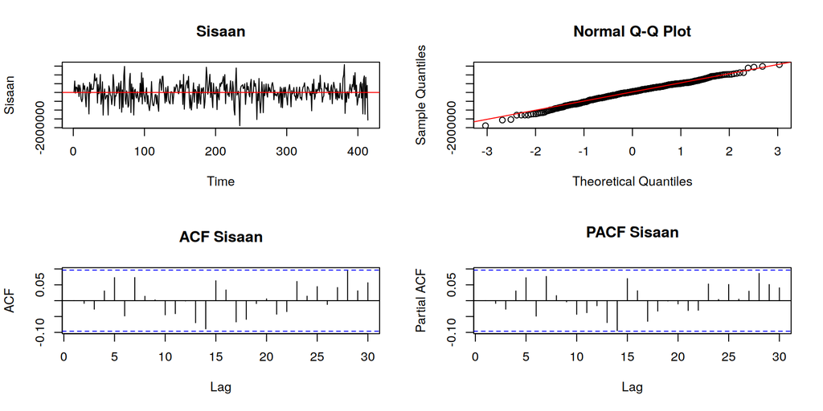

```r
res <- residuals(best)
par(mfrow = c(2, 2))
plot(res, type = "l", main = "Sisaan", ylab = "Sisaan"); abline(h = 0, col = "red")
qqnorm(res); qqline(res, col = "red")
acf(res, lag.max = 30, main = "ACF Sisaan")
pacf(res, lag.max = 30, main = "PACF Sisaan")
```

```r
par(mfrow = c(1, 1))
```

```r
cat("1) Normalitas\n"); print(shapiro.test(res)); print(tseries::jarque.bera.test(res))
```

```
## 1) Normalitas
```

```
##
##  Shapiro-Wilk normality test
##
## data:  res
## W = 0.99265, p-value = 0.03968
```

```
##
##  Jarque Bera Test
##
## data:  res
## X-squared = 6.5273, df = 2, p-value = 0.03825
```

```r
cat("\n2) Autokorelasi (Ljung-Box, fitdf = 3)\n"); print(Box.test(res, lag = 20, type = "Ljung-Box", fitdf = 3))
```

```
##
## 2) Autokorelasi (Ljung-Box, fitdf = 3)
```

```
##
##  Box-Ljung test
##
## data:  res
## X-squared = 18.965, df = 17, p-value = 0.3306
```

```r
cat("\n3) Nilai tengah sisaan = 0\n"); print(t.test(res, mu = 0))
```

```
##
## 3) Nilai tengah sisaan = 0
```

```
##
##  One Sample t-test
##
## data:  res
## t = 0.44612, df = 413, p-value = 0.6557
## alternative hypothesis: true mean is not equal to 0
## 95 percent confidence interval:
##  -40924.98  64954.40
## sample estimates:
## mean of x
##  12014.71
```

```r
cat("\n4) Kehomogenan ragam (Ljung-Box pada sisaan kuadrat / efek ARCH)\n")
```

```
##
## 4) Kehomogenan ragam (Ljung-Box pada sisaan kuadrat / efek ARCH)
```

```r
print(Box.test(res^2, lag = 10, type = "Ljung-Box"))
```

```
##
##  Box-Ljung test
##
## data:  res^2
## X-squared = 16.739, df = 10, p-value = 0.08034
```

Ringkasan hasil uji sisaan ($\alpha$ = 5%):

| Asumsi | P.value | Keputusan |
| --- | --- | --- |
| Sisaan saling bebas (tidak ada autokorelasi) | 0.33060 | Terpenuhi |
| Nilai tengah sisaan = 0 | 0.65570 | Terpenuhi |
| Sisaan menyebar normal (Shapiro-Wilk) | 0.03968 | Tidak terpenuhi |
| Sisaan menyebar normal (Jarque-Bera) | 0.03825 | Tidak terpenuhi |
| Ragam sisaan homogen (tidak ada efek ARCH) | 0.08034 | Terpenuhi |

Berdasarkan plot dan uji, sisaan **tidak berautokorelasi** (Ljung-Box *p-value* 0,33; ACF/PACF sisaan berada di dalam batas), **bernilai tengah nol** (*p-value* 0,66), dan **ragamnya homogen** (tidak ada efek ARCH, *p-value* 0,08). Asumsi **normalitas hanya terpenuhi secara marginal**: uji Shapiro-Wilk dan Jarque-Bera memberi *p-value* sekitar 0,04 (sedikit di bawah 0,05) sehingga secara formal normalitas ditolak. Pada Q-Q plot, penyimpangan terutama terjadi di ekor, yang berasal dari beberapa hari dengan penurunan suhu mendadak. Dengan 414 amatan, penyimpangan ringan seperti ini wajar dan umumnya tidak banyak memengaruhi pendugaan titik, tetapi selang kepercayaan ramalan perlu ditafsirkan dengan hati-hati.

# 9 Tahap 7: Overfitting

Model ARIMA(2,1,1) dibandingkan dengan model yang ordenya dinaikkan satu pada AR atau MA, yaitu ARIMA(3,1,1) dan ARIMA(2,1,2).

```r
m311 <- Arima(train, order = c(3,1,1), lambda = lambda)
m212 <- Arima(train, order = c(2,1,2), lambda = lambda)
cat("==== ARIMA(3,1,1) ====\n"); print(coeftest(m311))
```

```
## ==== ARIMA(3,1,1) ====
```

```
##
## z test of coefficients:
##
##        Estimate  Std. Error  z value  Pr(>|z|)
## ar1  0.29774072  0.05402351   5.5113 3.562e-08 ***
## ar2  0.15347365  0.05390475   2.8471  0.004412 **
## ar3 -0.00062259  0.05254826  -0.0118  0.990547
## ma1 -0.95027059  0.02119984 -44.8244 < 2.2e-16 ***
## ---
## Signif. codes:  0 '***' 0.001 '**' 0.01 '*' 0.05 '.' 0.1 ' ' 1
```

```r
cat("\n==== ARIMA(2,1,2) ====\n"); print(coeftest(m212))
```

```
##
## ==== ARIMA(2,1,2) ====
```

```
##
## z test of coefficients:
##
##       Estimate Std. Error z value Pr(>|z|)
## ar1  0.2885425  0.6329735  0.4559   0.6485
## ar2  0.1556832  0.2108288  0.7384   0.4603
## ma1 -0.9412820  0.6434507 -1.4629   0.1435
## ma2 -0.0084033  0.5992956 -0.0140   0.9888
```

```r
data.frame(Model = c("ARIMA(2,1,1)", "ARIMA(3,1,1)", "ARIMA(2,1,2)"),
           AIC = c(AIC(m211), AIC(m311), AIC(m212)))
```

| Model | AIC |
| --- | --- |
| ARIMA(2,1,1) | 12096.41 |
| ARIMA(3,1,1) | 12098.41 |
| ARIMA(2,1,2) | 12098.41 |

Pada ARIMA(3,1,1), parameter tambahan AR3 tidak signifikan (*p-value* 0,99). Pada ARIMA(2,1,2), parameter MA2 tidak signifikan (*p-value* 0,99) dan bahkan seluruh parameter ikut menjadi tidak signifikan. Penambahan parameter tidak memperbaiki model, sehingga **tidak terjadi *overfitting* yang bermanfaat dan ARIMA(2,1,1) tetap menjadi model terbaik**.

# 10 Tahap 8: Peramalan

## 10.1 Peramalan pada Data Uji

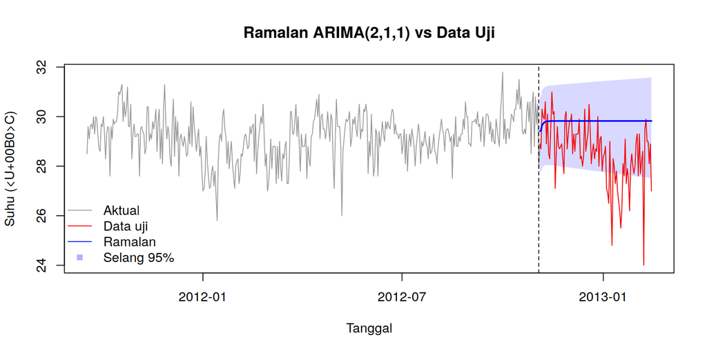

```r
h  <- length(test)
fc <- forecast::forecast(best, h = h, level = 95)
tgl.uji <- dat$Date[(n.train + 1):nrow(dat)]

plot(dat$Date, dat$TG, type = "l", col = "grey60", xlab = "Tanggal", ylab = "Suhu (°C)",
     main = "Ramalan ARIMA(2,1,1) vs Data Uji", ylim = range(dat$TG, fc$lower, fc$upper))
polygon(c(tgl.uji, rev(tgl.uji)), c(fc$lower, rev(fc$upper)), col = rgb(0,0,1,0.15), border = NA)
lines(tgl.uji, test, col = "red")
lines(tgl.uji, fc$mean, col = "blue", lwd = 2)
abline(v = dat$Date[n.train], lty = 2)
legend("bottomleft", c("Aktual", "Data uji", "Ramalan", "Selang 95%"),
       col = c("grey60", "red", "blue", rgb(0,0,1,0.3)), lty = c(1,1,1,NA), pch = c(NA,NA,NA,15), bty = "n")
```

```r
acc <- accuracy(fc$mean, test)
acc[, c("RMSE", "MAE", "MAPE")]
```

```
##     RMSE      MAE     MAPE
## 1.787747 1.413020 5.131447
```

```r
cat("Cakupan selang 95% terhadap data uji :", round(mean(test >= fc$lower & test <= fc$upper) * 100, 1), "%\n")
```

```
## Cakupan selang 95% terhadap data uji : 81.6 %
```

Karena model memiliki $d = 1$ dengan komponen MA dominan, ramalan jangka panjang cenderung mendatar (mendekati suatu nilai konstan) dan selang kepercayaannya melebar seiring bertambahnya horizon. Pada data uji, ramalan memberikan RMSE sekitar 1,79 °C, MAE sekitar 1,41 °C, dan MAPE sekitar 5,1%. Selang kepercayaan 95% hanya memuat sekitar 82% data uji, lebih rendah dari 95% yang diharapkan, karena data uji berisi periode penurunan suhu yang lebih tajam dan sering dibanding data latih, dan karena ramalan 103 hari sekaligus bersifat sangat jauh ke depan. Artinya, model cukup baik menangkap level rata-rata suhu, tetapi tidak dapat meramalkan fluktuasi harian jangka panjang.

## 10.2 Peramalan 30 Hari ke Depan (Seluruh Data)

Model dengan orde terpilih diduga ulang menggunakan seluruh 517 amatan, lalu digunakan untuk meramalkan 30 hari setelah 14 Februari 2013.

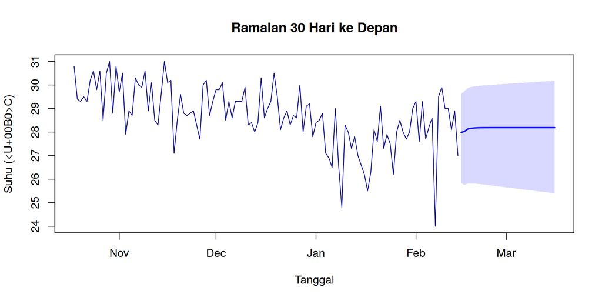

```r
final <- Arima(dat$TG, order = c(2,1,1), lambda = lambda)
ff <- forecast::forecast(final, h = 30, level = 95)
tgl.depan <- seq(max(dat$Date) + 1, by = "day", length.out = 30)
plot(tail(dat$Date, 120), tail(dat$TG, 120), type = "l", col = "navyblue",
     xlim = range(c(tail(dat$Date, 120), tgl.depan)), ylim = range(tail(dat$TG, 120), ff$lower, ff$upper),
     xlab = "Tanggal", ylab = "Suhu (°C)", main = "Ramalan 30 Hari ke Depan")
polygon(c(tgl.depan, rev(tgl.depan)), c(ff$lower, rev(ff$upper)), col = rgb(0,0,1,0.15), border = NA)
lines(tgl.depan, ff$mean, col = "blue", lwd = 2)
```

```r
data.frame(Tanggal = tgl.depan, Ramalan = round(as.numeric(ff$mean), 2),
           Bawah95 = round(as.numeric(ff$lower), 2), Atas95 = round(as.numeric(ff$upper), 2))
```

| Tanggal | Ramalan | Bawah95 | Atas95 |
| --- | --- | --- | --- |
| 2013-02-15 | 27.98 | 25.84 | 29.62 |
| 2013-02-16 | 28.02 | 25.75 | 29.73 |
| 2013-02-17 | 28.13 | 25.81 | 29.86 |
| 2013-02-18 | 28.16 | 25.81 | 29.91 |
| 2013-02-19 | 28.17 | 25.81 | 29.94 |
| 2013-02-20 | 28.18 | 25.80 | 29.95 |
| 2013-02-21 | 28.19 | 25.79 | 29.97 |
| 2013-02-22 | 28.19 | 25.77 | 29.98 |
| 2013-02-23 | 28.19 | 25.75 | 29.99 |
| 2013-02-24 | 28.19 | 25.74 | 30.00 |

[output cut: 20 more lines]

# 11 Kesimpulan

Data suhu harian Jakarta Kemayoran (517 amatan) dibagi menjadi 414 data latih dan 103 data uji. Data latih belum stasioner dalam ragam (selang Box-Cox tidak memuat 1) sehingga ditransformasi Box-Cox ($\lambda = 5$), dan ACF yang meluruh lambat menyebabkan dilakukan *differencing* orde 1. Dari ACF, PACF, dan EACF diperoleh lima model tentatif, dan **ARIMA(2,1,1)** dipilih karena seluruh parameternya signifikan serta memiliki AIC terkecil. Sisaan model tidak berautokorelasi, bernilai tengah nol, dan beragam homogen, sedangkan normalitas hanya terpenuhi secara marginal (*p-value* sekitar 0,04). Pengecekan *overfitting* (ARIMA(3,1,1) dan ARIMA(2,1,2)) tidak menemukan model yang lebih baik. Pada data uji, ramalan memiliki RMSE sekitar 1,79 °C dan MAPE sekitar 5,1%.